# Using the Excel Configuration Tool

Aaron White

Note: This is an [R Markdown](http://rmarkdown.rstudio.com) Notebook. When you execute code within the notebook, the results appear beneath the code.

```r
# Import the functions and your username, password, and url settings defined in settings.R
source('settings.R')
```

[output not shown]

[output not shown]

```r
setDHIS2_credentials('dhis2_demo')
```

# Table of Contents

- Creating the file
- Scraping the file
- Uploading the file

## Creating the file

There’s a template file that can serve as a starting point for configuring a new form/program in DHIS2. Because the UI can be a headache when trying to configure a large number of dataElements and disaggregations, this file can help ease your pain. This only works for the aggregate space within DHIS2. Unfortunately, you’re on your own for Tracker at the moment.

Open the file. You’ll see multiple tabs in the worksheet, each corresponding to the different aggregate configuration pieces you’ll need to make when setting up a new form. Because you need to bounce around to multiple places when setting up configurations in DHIS2, this lets you do that more easily. Start with the `Data Elements` tab.

Just like in the UI, you have columns for each property of the dataElements you want to create. Fill in the Data Element Name, Short Name, Code (if applicable), and Description of the dataElements you want to create. Be careful with your shortNames since those values also have to be unique and can cause a lot of headaches if you have duplicates in a configuration file!

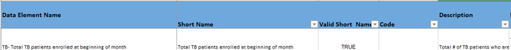

Next, scroll to the right and fill in the Form Name, Dataset, Data Element Group, Value Type, and Aggregation Type columns. The Dataset and Data Element Group columns have a validation rule that provides a dropdown from the Data Sets and Data Element Groups tabs respectively. As you fill out information about dataElements, you can flip over to those tabs and add options as needed.

Data Sets:

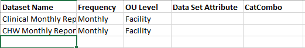

Data Element Groups:

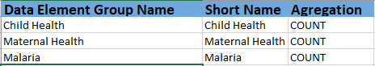

Finally, add in the Category Combo Name and assign the categories you want to use. Just like the Data Sets and Data Element groups, there are dropdowns that limit what you can enter. If you need to repeat a categoryCombo, just repeat the whole line with the assigned categories. The full file has a better example of how that works. Here’s a screen shot of the first row:

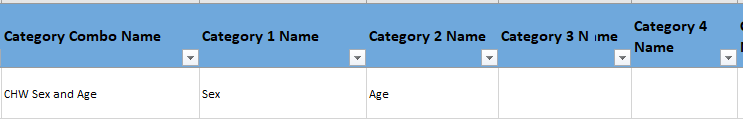

And the Category Options tab:

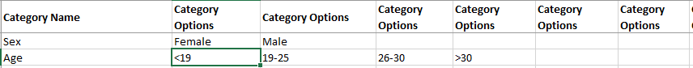

## Converting to DHIS2 IDs

We’ll use this later on too but here’s a preview. The *prepareDHIS2_dataValues()* function does that thorough checking of dataElements + categoryOptionCombos investigation since we need the IDs to match exactly when uploading to the system. The reason this is a challenge is that each categoryCombo generates it’s own unique set of categoryOptionCombos. So if “HIV Testing Age and Sex” has a categoryOptionCombo of “15, M” and “TB Treatment Age” also happens to have “15, M”, the categoryOptionCombo on the backend will have a different ID. Here’s how to use it:

```r
# ready_for_upload <- prepareDHIS2_dataValues(converted_df, usr, pwd, url)
# head(ready_for_upload)
```